# Construindo gráficos com ggplot2

Paulo Vinícius Soares

11 de julho de 2018

Vamos importar as nossas bibliotecas e nosso *dataset*.

```r
library(tidyverse)
series_imdb <- read_csv("../database/series_from_imdb.csv")
```

# Introdução

Serão abordados três gráficos: *boxplot*, gráfico de linhas e o gráfico de barras (No meu exemplo de análise vocês podem encontrar um *scatterplot* também).

# Boxplot

O *boxplot* é utilizado para representar a distribuição dos dados, de forma que temos melhor noção de mediana, máximos, mínimos e podemos detectar *outliers*. Podemos verificar como se comportam as notas de Black Mirror, por exemplo:

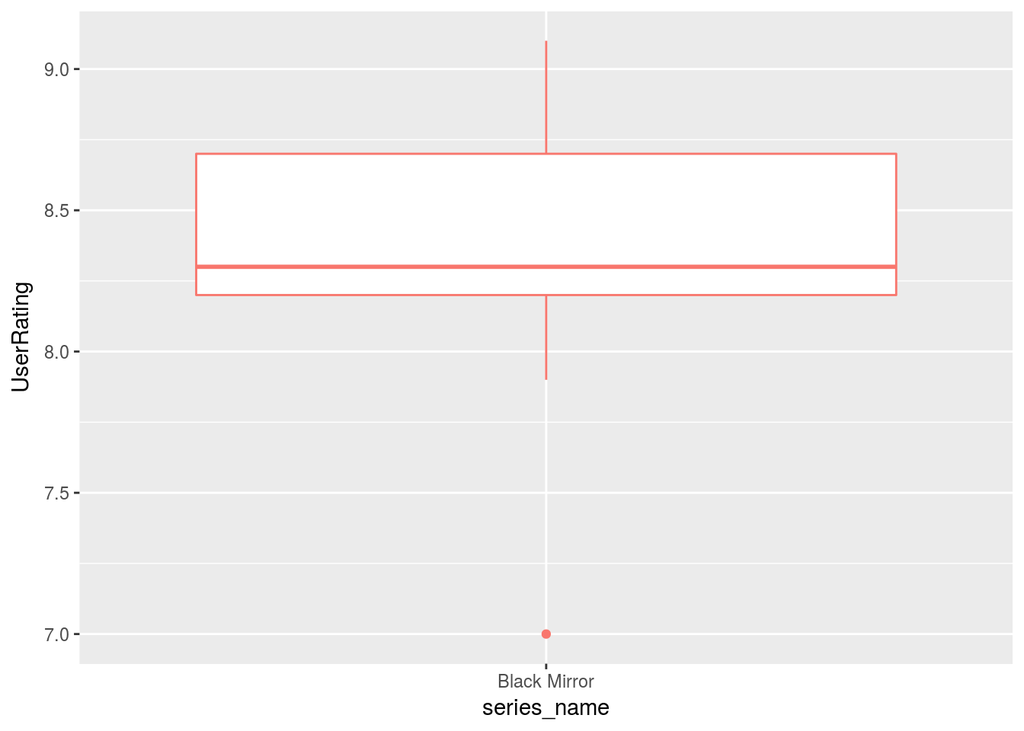

```r
series_imdb %>%
  filter(series_name %in% "Black Mirror") %>%
  ggplot(aes(x=series_name, y=UserRating)) + geom_boxplot(aes(color=series_name), show.legend=FALSE)
```

# Gráfico de linhas

O gráfico de linhas é utilizado para representar a evolução do dado com base em uma linha do tempo ou baseado em alguma categoria. Por exemplo, podemos verificar as notas de Black Mirror ao longo do tempo. Elas caem, elas aumentam, elas se mantêm constantes?

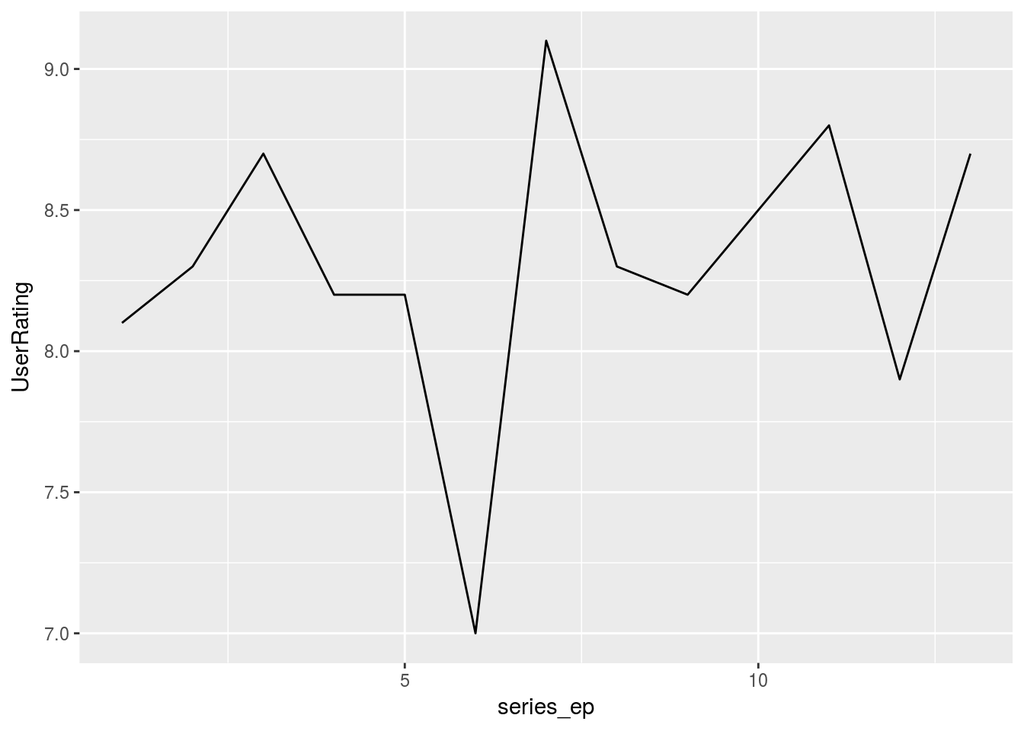

```r
series_imdb %>%
  filter(series_name %in% "Black Mirror") %>%
  ggplot(aes(x=series_ep, y=UserRating)) + geom_line()
```

# Gráfico de barras

O gráfico de barras é utilizado para representar *ranking* com base em dados absolutos, geralmente. Vamos comparar a nota média entre algumas séries e ver qual a melhor avaliada.

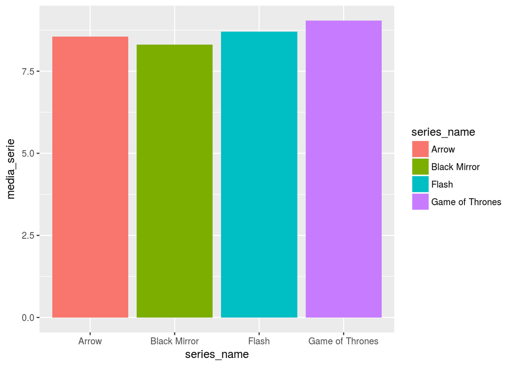

```r
series_avaliadas <- c("Black Mirror", "Flash", "Arrow", "Game of Thrones")

series_imdb %>%
  filter(series_name %in% series_avaliadas) %>%
  group_by(series_name) %>%
  summarise(media_serie = mean(UserRating)) %>%
  ggplot(aes(x=series_name, y=media_serie)) + geom_bar(stat="identity", aes(fill=series_name))
```

Você também pode ordenar os gráficos usando a função `reorder()` no parâmetro x do ggplot:

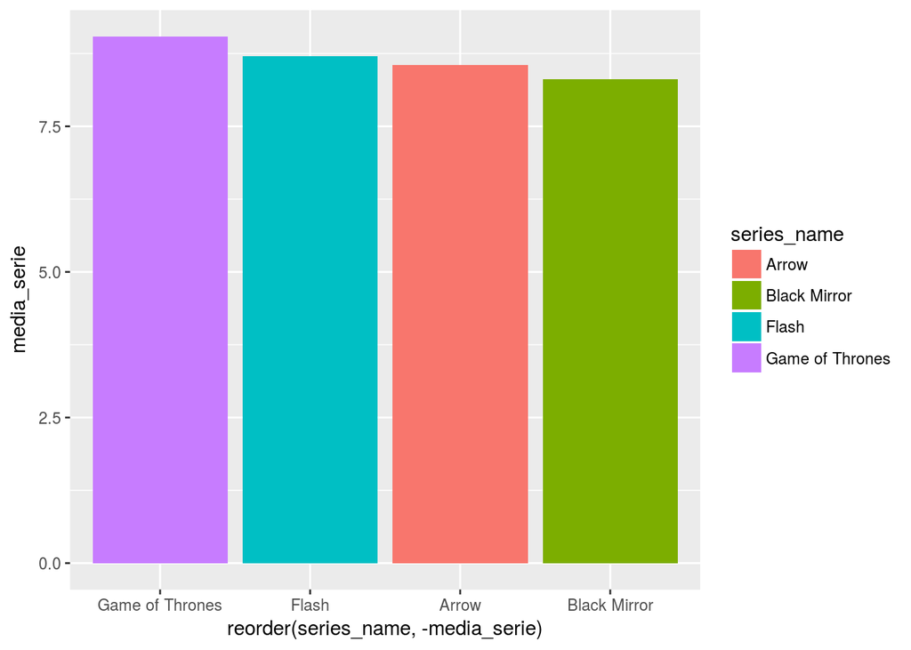

```r
# Usando - você ordena de forma decrescente
series_imdb %>%
  filter(series_name %in% series_avaliadas) %>%
  group_by(series_name) %>%
  summarise(media_serie = mean(UserRating)) %>%
  ggplot(aes(x=reorder(series_name, -media_serie), y=media_serie)) + geom_bar(stat="identity", aes(fill=series_name))
```

Para mais informações, você pode acessar os links do [R Graph Gallery](https://www.r-graph-gallery.com/).